# Benchmarking STAR Testing - Complete Sample

Samantha Sevilla

3/4/2022

## Background

In this benchmarking experiment, STAR was compared to NOVOAlign, currently utilized in our iCLIP pipeline. STAR version 2.7.8a was used (https://github.com/alexdobin/STAR/releases).

For each read, an alignment was assessed for any gaps, with two possible scenarios:

1. alignment—gap—alignment
2. alignment—gap–insertion/deletion—alignment

For all reads that match outcome #1, reads were counts. For gaps with reads larger than 100, overhang and parent were assigned to the alignments as follows:

3. overhang: the smaller length of the two alignments
4. parent: the larger length of the two alignments

Ratios were calculated for each read that met this criterion. For example #5 would have a ratio of 2/70, #6 would have a ratio of 2/70, and #7 would not be included due to the gap being <100.

5. alignment1(N=2)—gap(N=100)—alignment2(N=70)
6. alignment3(N=70)—gap(N=100)—alignment4(N=2)
7. alignment3(N=70)—gap(N=10)—alignment4(N=2)

8. alignment1(N=2)—gap1(N=100)—alignment2(N=70)—gap2(N=100)—alignment4(N=2)
9. alignment3(N=70)—gap1(N=100)—alignment4(N=2)–gap2(N=100)—alignment4(N=2)–gap3(N=100)—alignment4(N=2)
10. alignment3(N=70)—gap1(N=100)—alignment4(N=2)–gap2(N=50)—alignment4(N=2)

# Variations Summary

| Alignment Flag | Description |
| --- | --- |
| outFilterMismatchNoverReadLmax | max number of mismatches per pair relative to read length: for 2x100b, max number of mis- |
| matches is 0.04*200=8 for the paired read |  |
| outFilterMismatchNmax | alignment will be output only if it has no more mismatches than this value. |
| outFilterMultimapNmax | max number of multiple alignments allowed for a read: if exceeded, the read is considered unmapped |
| outSJfilterReads | which reads to consider for collapsed splice junctions output |
| outSJfilterCountTotalMin | minimum total (multi-mapping+unique) read count per junctionfor: (1) non-canonical motifs, (2) GT/AG and CT/AC motif, (3) GC/AG andCT/GC motif, (4) AT/AC and GT/AT motif. -1 means no output for thatmo… |
| alignEndsType | type of read ends alignment; fully extend only the 5p of the read1, all other ends: local alignment |
| outSAMunmapped | output of unmapped reads in the SAM format |
| outSAMattributes | a string of desired SAM attributes, in the order desired for the output SAM |
| outFilterType | keep only those reads that contain junctions that passed filtering into SJ.out.tab |
| outFilterScoreMin | alignment will be output only if its score is higher than or equal to this value. |
| outFilterMultimapScoreRange | the score range below the maximum score for multimapping alignments |
| sjdbScore | extra alignment score for alignments that cross database junctions |
| outSJfilterOverhangMin | minimum overhang length for splice junctions on both sides for: (1)non-canonical motifs, (2) GT/AG and CT/AC motif, (3) GC/AG and CT/GCmotif, (4) AT/AC and GT/AT motif. -1 means no output for that mot… |
| alignIntronMax | maximum intron length |
| outFilterMatchNmin | alignment will be output only if the number of matched bases is higher |
| than or equal to this value. |  |
| outFilterMatchNminOverLread | sam as outFilterMatchNmin, but normalized to the read length (sum of |
| mates’ lengths for paired-end reads). |  |
| alignSJDBoverhangMin | minimum overhang for annotated junctions |
| alignSJoverhangMin | minimum overhang for unannotated junctions |

| Alignment Flag | star_2e | star_2h | star_2i | star_2j | star_clipseqtools_v1 | star_clipseqtools_v2 |
| --- | --- | --- | --- | --- | --- | --- |
| outFilterMismatchNoverReadLmax | 0.04 | 0.04 | 0.04 | 0.04 | 0.04 | 0.04 |
| outFilterMismatchNmax | 999 | 999 | 999 | 999 | 999 | 999 |
| outFilterMultimapNmax | 999 | 999 | 999 | 999 | 20 | 20 |
| outSJfilterReads | All | All | All | All | All | All |
| outSJfilterCountTotalMin | 10 5 5 5 | 10 5 5 5 | 10 5 5 5 | 10 5 5 5 | 3 1 1 1 | 3 1 1 1 |
| alignEndsType | Extend5pOfRead1 | Extend5pOfRead1 | EndToEnd | EndToEnd | Local | Local |
| outSAMunmapped | None | None | None | None | None | None |
| outSAMattributes | Standard | Standard | Standard | Standard | All | All |
| outFilterType | Normal | Normal | Normal | Normal | Normal | Normal |
| outFilterScoreMin | 0 | 0 | 0 | 0 | 0 | 0 |
| outFilterMultimapScoreRange | 0 | 5 | 5 | 5 | 0 | 0 |
| sjdbScore | 0 | 0 | 0 | 0 | 2 | 2 |
| outSJfilterOverhangMin | 15 6 6 6 6 | 20 10 10 10 10 | 15 6 6 6 6 | 15 6 6 6 6 | 30 12 12 12 | 30 12 12 12 |
| alignIntronMax | 1000000 | 1000000 | 1000000 | 1000000 | 50000 | 1000000 |
| outFilterMatchNmin | 10 | 10 | 10 | 10 | 15 | 15 |
| outFilterMatchNminOverLread | 0.6 | 0.6 | 0.6 | 0.6 | 0.9 | 0.9 |
| alignSJDBoverhangMin | 5 | 5 | 5 | 3 | 5 | 5 |
| alignSJoverhangMin | 5 | 5 | 5 | 5 | 5 | 5 |

# Alignment

Alignment statistics were generated for each version type, including a comparison between the total number of reads uniquely mapped to those that were unmapped, and the total number of reads unique mapped and those that were multimapped.

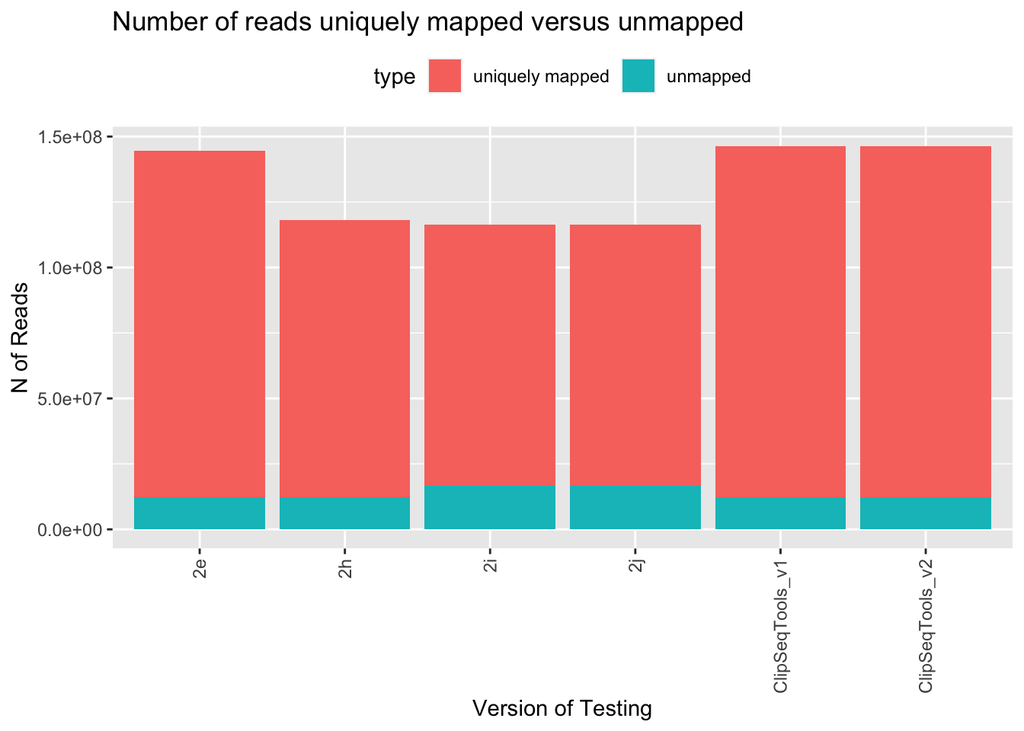

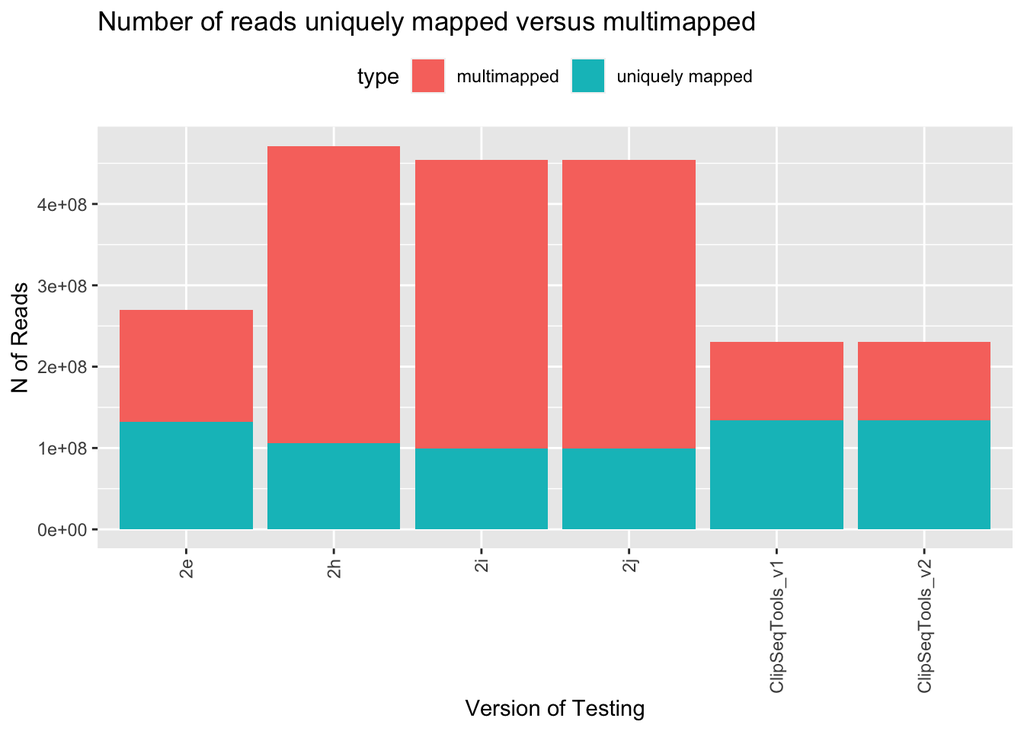

# Number of Gaps

Reads were found to have a variable number of gaps. A total count of these gaps were recorded regardless of length. Then, these were subset for only reads with any gap greater than 100 bp in length. The graphic below shows each version (X) by the total number of reads (Y), stratified by the N of gaps found (1,2,3). The bars are split by the gap_subcount, which is the number of gaps within the read that is greater than 100 bp. For example, in reads for 2e in which there was 1 gap found, approximately 25% of those reads had no gaps (gap_subcount=0) that were greater than the minimum threshold of 100 (salmon colored) and approxmiately 75% of those reads were greater than 100 (gree colored). The second graphic subsets for only reads that included gaps >100bp.

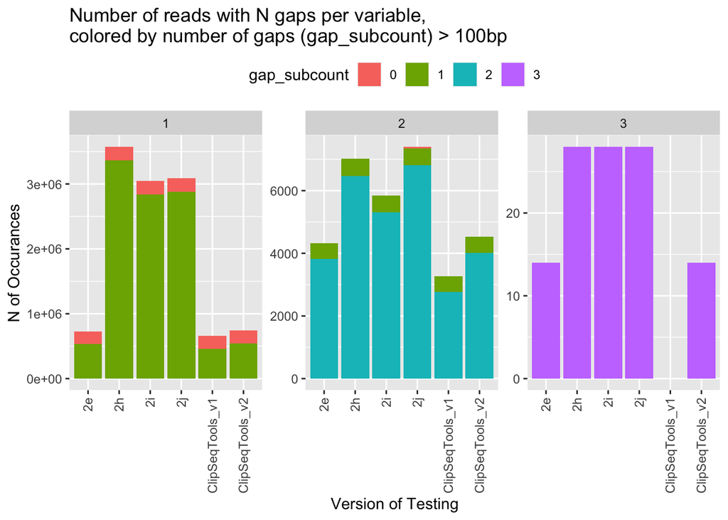

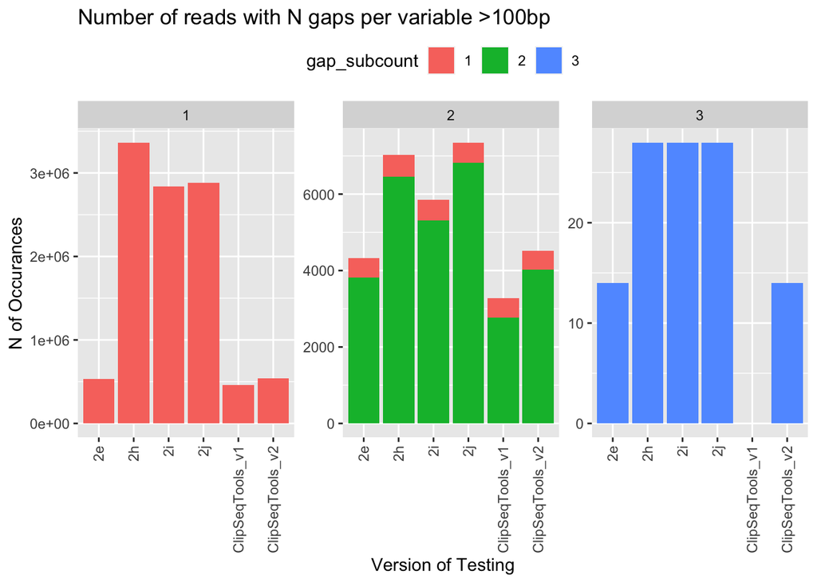

The data table includes counts of all reads with at least one gap > 100 bp.

|  | gap_1 | gap_2 | gap_3 | gap_total |
| --- | --- | --- | --- | --- |
| 2e | 530,996 | 4,325 | 14 | 535,335 |
| 2h | 3,365,278 | 7,021 | 28 | 3,372,327 |
| 2i | 2,841,672 | 5,848 | 28 | 2,847,548 |
| 2j | 2,878,742 | 7,351 | 28 | 2,886,121 |
| ClipSeqTools_v1 | 458,142 | 3,274 | 0 | 461,416 |
| ClipSeqTools_v2 | 540,312 | 4,522 | 14 | 544,848 |

# Gap Features

## Summary Tables

Summary table of alignment variation by the length of overhang or length of gap. Values indicate the number of times this feature was observed. Only gaps >100bp, with overhang/parent ratios <.20 are considered.

[output not shown]

|  | id | [0-1,000) | [1,000-100,00) | [10,000-20,000) | [20,000-30,000) | [30,000-40,000) | [40,000-50,000) | [50,000-100,000) | [100,000<) |
| --- | --- | --- | --- | --- | --- | --- | --- | --- | --- |
| 1 | 2e | 205697 | 170726 | 13230 | 5428 | 2871 | 2511 | 14616 | 124098 |
| 2 | 2h | 373551 | 772350 | 346609 | 23266 | 32762 | 27412 | 76469 | 1726422 |
| 3 | 2i | 303432 | 691866 | 337545 | 18849 | 28183 | 18348 | 52704 | 1401992 |
| 4 | 2j | 325740 | 707717 | 338643 | 19075 | 28445 | 18350 | 52762 | 1402261 |
| 5 | ClipSeqTools_v1 | 256826 | 183641 | 13346 | 5304 | 1819 | 1945 | 1058 | 248 |
| 6 | ClipSeqTools_v2 | 256947 | 184236 | 13449 | 5465 | 1783 | 2001 | 6945 | 78066 |

## Summary Plots

### Overhang length

Summary plot of ratios of overhang/parent alignment (see above for definitions) by the number of times they occur within the alignment variation. Only ratios under 0.2 are shown.

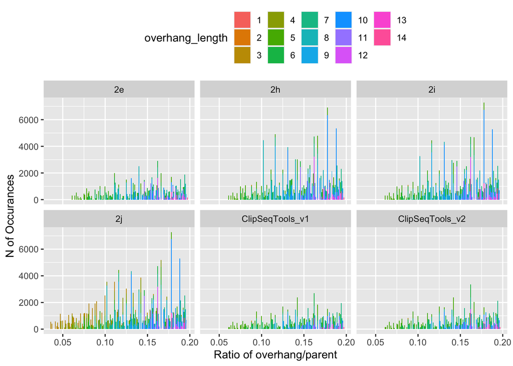

### Gap length

Summary plot of ratios of overhang/parent by the number of times they occur within the alignment variation, colored by the length of the gap observed. Only ratios under 0.2 are shown.

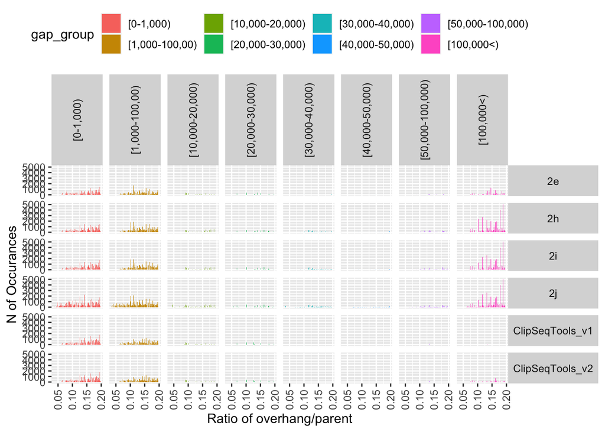

# Conclusion

Based on the read distribution of mapping (uniquely mapped vs unmapped, uniquely mapped vs multimapped), reads that have a low gap number (N<3), reads that have a higher ratio of overhang to parent (ratio >0.2), and gap length (gaps <100,000) the best performing parameters include ClipSeqTools_v1, ClipSeqTools_v2, and 2e.